# we20153_COMSM014

### COMSM0140: Internet Economics and Financial Technology 2023. Main coursework.

### Radmehr Ghassabtabarshiadeh

Part A

A/B testing to test the null hypothesis "there is no significant difference between the two traders" and the alternative hypothesis of there being a significant difference between the two traders, with alpha set to 0.05. A market session will run with the specification mentioned on the brief. Start time and end time are set to 0 and 3600 seconds (1 hour) respectively with order interval of 60 seconds in parts A-C. This was chosen so sufficient data collection and trades take place in each sessions. After the simulation are complete the accumulated average profit of each trader type is taken. To do hypothesis testing, the collected averages, are passed into Shapiro-Wilk test to understand their distribution, then either t-test or Mann-Whitney-U test are utilised as the parametric and non-parametric test respectively. Different helper functions are used and are in helper.py with explanation of what they do.

```python
from helper import *
import numpy as np

supply_range = (310, 310)
demand_range = (250, 490)
start_time = 0
end_time = 60*60
```

```python
n500mean_shvr, n500mean_zic = run_market_sim(trial_id="n500", no_sessions=500, R=50, n=20, supply_range=supply_range, demand_range=demand_range, start_time=start_time, end_time=end_time, path='n500_avg_balance.csv')
n50mean_shvr, n50mean_zic = run_market_sim(trial_id="n50", no_sessions=50, R=50, n=20, supply_range=supply_range, demand_range=demand_range, start_time=start_time, end_time=end_time, path='n50_avg_balance.csv')
```

```
(248, 252) number of times traders had more profit than the other: (shvr, zic)
(24, 26) number of times traders had more profit than the other: (shvr, zic)
```

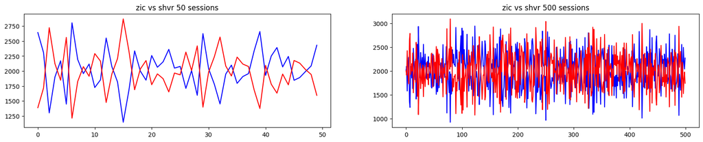

```python
plot_performance(n50mean_zic, n500mean_zic, n50mean_shvr, n500mean_shvr)
print(compare(n500mean_shvr, n500mean_zic), "number of times traders had more profit than the other: (shvr, zic)")
print(compare(n50mean_shvr, n50mean_zic), "number of times traders had more profit than the other: (shvr, zic)")
```

The plots above showcase what was the average profit, a trader made at the end of a session, zic traders being blue and shvr traders being red. It is observed that the profitability is shared roughly equally between the two traders. it shows, that there is no significant difference between the two traders when it comes to average profit in the market when the number of traders is equally distributed.

```python
_, pvalue50_shvr = stats.shapiro(n500mean_shvr)
_, pvalue500_shvr = stats.shapiro(n50mean_shvr)
_, pvalue500_zic = stats.shapiro(n500mean_zic)
_, pvalue50_zic = stats.shapiro(n50mean_zic)
print(pvalue50_shvr, pvalue500_zic, pvalue50_zic, pvalue500_shvr)
```

```
0.38963526487350464 0.37040531635284424 0.7784656286239624 0.7998491525650024
```

Since the market is populated with similar ratios of buyers and sellers of each type, the variance of the two trader's profits is also roughly similar. As the output show, both datasets are following a normal distribution therefore, a t-test can be used.

```python
_, p_val50 = stats.ttest_ind(n50mean_zic, n50mean_shvr)
print(p_val50, 'p val for 50 sessions')
_, p_val500 = stats.ttest_ind(n500mean_zic, n500mean_shvr)
print(p_val500, 'p val for 500 sessions')
```

```
0.4100452817469036 p val for 50 sessions
0.9907804259631603 p val for 500 sessions
```

In the simulated market sessions, the p value for both sessions, is above the threshold of 0.05, meaning we do not have sufficient evidence to reject the null hypothesis. In other words, we can conclude that there is no significant difference between the two trader's performance when comparing the average profit per session.

PART B

Below, modifies the previously used code to accommodate changes to ratios by collecting and returning their average profit at the end of each session in a pair. For each pair of data, they will be tested to see whether they are normally distributed using Shapiro-Wilk and then appropriate hypothesis testing is applied. Another thing to consider is the variance of the data, since there are different number of traders in the market, the variance difference will be high, so Welch's t-test is utilised here when data is parametric.

```python
R = [10, 20, 30, 40, 50, 60, 70, 80, 90]

res50 = R_market_run(R, 50, 20, supply_range=supply_range, demand_range=demand_range, start_time=start_time, end_time=end_time) #9 arr corresponding to each ratio, res[n][0]=shvr, [n][1]=zic each 50 long                                                                                                             #res[n][0] = shvr, res[n][1] = zic
res500 = R_market_run(R, 500, 20, supply_range=supply_range, demand_range=demand_range, start_time=start_time, end_time=end_time) #same as above but 500 long
```

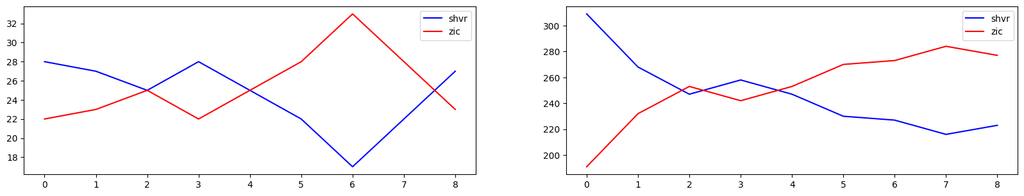

```python
plot_wins(res50, res500)
```

```python
p_vals_50 = collect_pvals_norm(res50)
p_vals_500 = collect_pvals_norm(res500)

p_res50 = A_B_test(p_vals_50, res50)
p_res500 = A_B_test(p_vals_500, res500)
```

```
n=50, ratio: 1 to 9 is NOT normal used NON-parametric test, p val is: 0.4120
n=50, ratio: 2 to 8 is NORMAL used parametric test, p val is: 0.4918
n=50, ratio: 3 to 7 is NORMAL used parametric test, p val is: 0.5277
n=50, ratio: 4 to 6 is NORMAL used parametric test, p val is: 0.0118
n=50, ratio: 5 to 5 is NORMAL used parametric test, p val is: 0.8209
n=50, ratio: 6 to 4 is NORMAL used parametric test, p val is: 0.0192
n=50, ratio: 7 to 3 is NORMAL used parametric test, p val is: 0.0122
n=50, ratio: 8 to 2 is NORMAL used parametric test, p val is: 0.2910
n=50, ratio: 9 to 1 is NORMAL used parametric test, p val is: 0.4769
n=500, ratio: 1 to 9 is NOT normal used NON-parametric test, p val is: 0.0000
n=500, ratio: 2 to 8 is NOT normal used NON-parametric test, p val is: 0.0020
n=500, ratio: 3 to 7 is NORMAL used parametric test, p val is: 0.4800
n=500, ratio: 4 to 6 is NORMAL used parametric test, p val is: 0.2887
n=500, ratio: 5 to 5 is NORMAL used parametric test, p val is: 0.6192
n=500, ratio: 6 to 4 is NORMAL used parametric test, p val is: 0.0692
n=500, ratio: 7 to 3 is NOT normal used NON-parametric test, p val is: 0.0173
n=500, ratio: 8 to 2 is NOT normal used NON-parametric test, p val is: 0.0001
n=500, ratio: 9 to 1 is NOT normal used NON-parametric test, p val is: 0.0017
```

PART C

Four trader types with different populations being tested to see which is the best. Having 'GVWY', 'SHVR', 'ZIC' and 'ZIP' traders at a predefined ratios below (note: to gather all permutations, np.roll is used). P values obtained are using either Anova test or Kruskal test depending on whether data is parametric or non-parametric, all means collected being normal is very unlikely, therefore only the non-parametric test (Kruskal) is expected to be used. Here rejecting the null hypothesis means there is a significant difference in the market but does not determine which trader is the best. Having a p value lower than 0.05 is expected in all sessions, and further analysis is needed to determine the best trader. Here a total of 100 independent sessions are ran on each ratio to obtain enough data for analysis and to allow the zip trader to adjust its hyperparameters better.

```python
t = [25, 25, 25, 25]
t1 = [40, 20, 20, 20]
t2 = [10, 30, 30, 30]
t3 = [70, 10, 10, 10]

four_25_100_sess, pval_25_n100 = run_market_sim_four("equal_500", 100, t, 20, supply_range=supply_range, demand_range=demand_range, start_time=start_time, end_time=end_time)

#res[i] = [mean[shvr], mean[gvwy], mean[zic], mean[zip]], each mean either 50 or 500 long where i is the permutation
res_40100, pvals40100 = [0] * 4, []
res_10_100, pvals10100= [0] * 4, []
res_70_100, pvals70100 = [0] * 4, []
for i in range(len(t)):

    forty_100, p40100 = run_market_sim_four(trial_id="40_"+str(i)+"_perm_500", no_sessions=100, t=np.roll(t1, i), n=20, supply_range=supply_range, demand_range=demand_range, start_time=start_time, end_time=end_time)
    res_40100[i] = forty_100
    pvals40100.append(p40100)

    ten_100, p10100 = run_market_sim_four(trial_id="10_"+str(i)+"_perm_500", no_sessions=100, t=np.roll(t1, i), n=20, supply_range=supply_range, demand_range=demand_range, start_time=start_time, end_time=end_time)
    res_10_100[i] = ten_100
    pvals10100.append(p10100)

    seventy_100, p70100 = run_market_sim_four(trial_id="70_"+str(i)+"_perm_500", no_sessions=100, t=np.roll(t1, i), n=20, supply_range=supply_range, demand_range=demand_range, start_time=start_time, end_time=end_time)
    res_70_100[i] = seventy_100
    pvals70100.append(p70100)
```

```python
print(pvals70100)
print(pval_25_n100)
print(pvals10100)
print(pvals40100)
```

```
[6.503205231878128e-26, 6.285072222433908e-39, 9.899168203870766e-15, 1.8239030135286042e-48]
6.353342094290095e-41
[1.791183010018632e-25, 5.803980173258521e-40, 3.9793407810632255e-15, 8.493893005327505e-42]
[1.2747508406824103e-29, 3.715662837182175e-45, 4.1865327141858616e-11, 2.5887012185409904e-37]
```

The p values collected are mostly all below the threshold of 0.05 leading to rejecting the null hypothesis and concluding that there is a significant difference between the traders. This was the expected output as the different ratios and nature of the traders will lead to such p values.

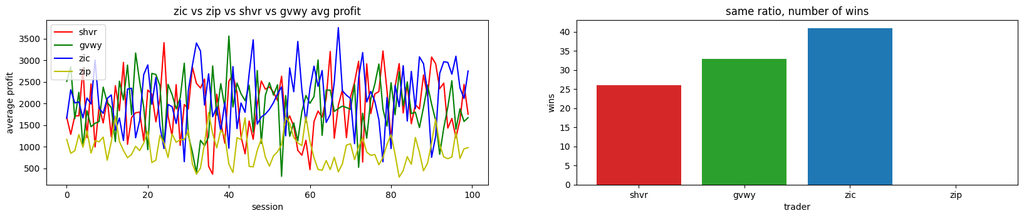

[figure not shown]

```python
plot_performance_same_ratio(four_25_100_sess)
plot_wins_4(res_40100, t1, res_10_100, t2, res_70_100, t3)
```

PART D.1:

To replicate the experiment, a single zipsh trader is in the market with 20 other zic traders, where the zipsh is a buyer. Goal is to evaluate zipsh's performance and monitor its improvement over each day. 30 independent runs are done to collect ZIPSH's average profit per second for each of its mutations to then plot it to understand whether there is an improvement after each mutation. Here k is set to 4, optimizer is 'ZIPSH' for its stochastic hill climber and a single session lasts 30 days and the evaluation stage remains untouched. The order intervals are set to 30 seconds, supply is (50,75) and demand curves are (125, 150) so zipsh can make profit and adapt how much. The initial hyperparameter beta and marginal_buy and are set to very low values (0.01 and 0.05 respectively) to highlight the adaptive process of zipsh.

```python
#30 sessions, start=0 end= 60*60*24*30 (30 days)
#hyper = [[b, m, ca, cr, mb]], index == day
n = 30
start_time=0
end_time=60*60*24*30
supply=(50, 75)
buy=(125, 150)
buyer_spec = [('ZIPSH', 1, {'k': 4, 'optimizer': 'ZIPSH'}), ('ZIC', 10)]
seller_spec = [('ZIC', 10)]
zipsh_profit, zic_profit, total_avg_profit_perS, hyper_params = run_market_sim_D("replicate", n, supply, buy, start_time, end_time, "replicate_avg_balance.csv", "replicate_strats.csv", buyer_spec, seller_spec)
betas = hyper_params[0]
momentums = hyper_params[1]
c_a = hyper_params[2]
c_r = hyper_params[3]
initial_margin = hyper_params[4]
```

The independent runs show that the single zipsh trader is indeed making a profit and improving itself in the market and returning a higher profit from the starting point. From extreme cases where it can make up to 500% the initial profit, with some cases where the profit is more modest. This is not always the case as there are times where the trader ends the session with a profit of 0 or less than. There seems to be a relation between the learning rate beta vals and the profit zipsh returns as the beta steadily increases, the profit seems to do the same. This is specially the case if the momentum values do not increase significantly since dramatic shifts seem to always result less profit than before. This can be due to having unstable momentum updates or overshooting the optimal solution leading to a dramatic decrease in the profit, as shown by the figures below (first few are plotted). The algorithm often switches to extreme values for marginal buy which leads it to have the highest profit however it does not adjust for low margins therefore struggling to make profit on lower trades. In conclusion, if the correct mutation is chosen with a steady increase in the beta vals while momentum is kept to a lower value, the trader starts to improve and return a profit, however when there is a dramatic change, the profitability of the traders falls massively.

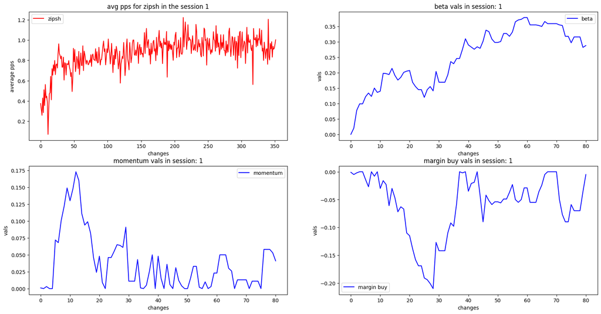

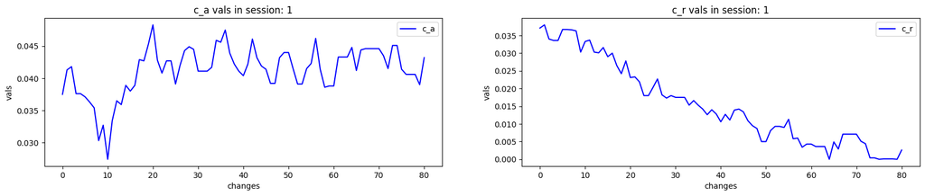

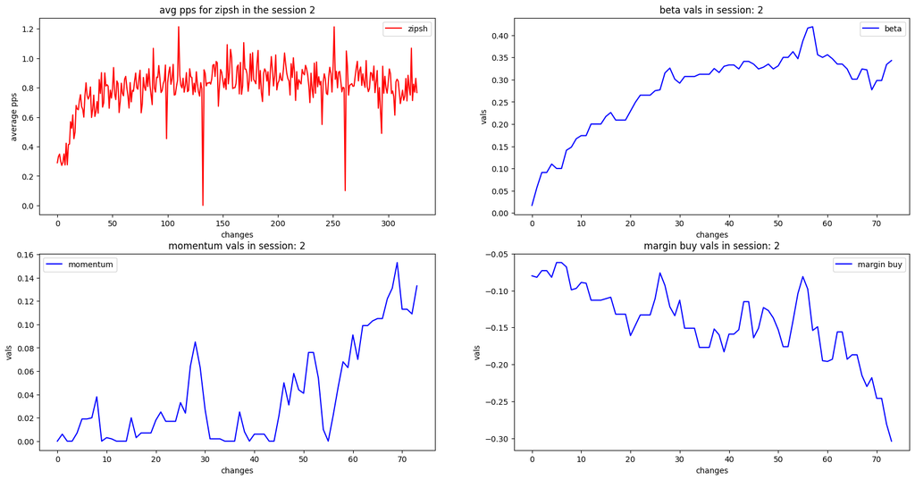

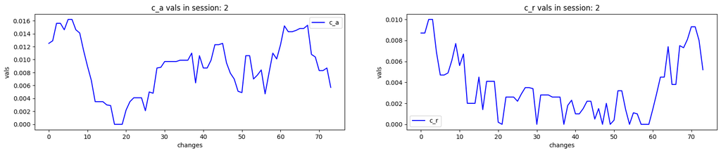

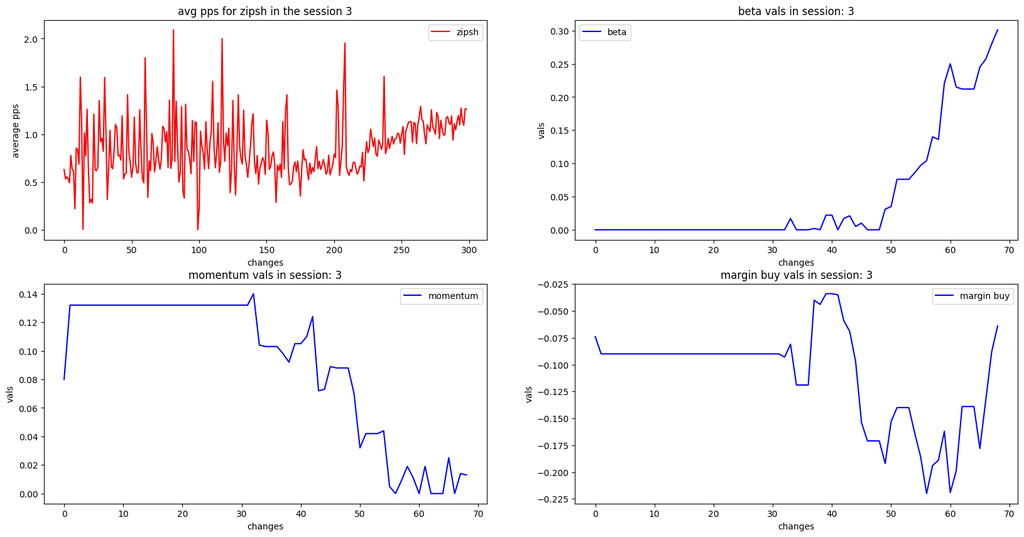

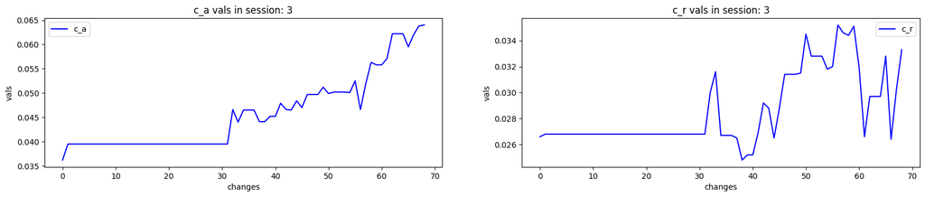

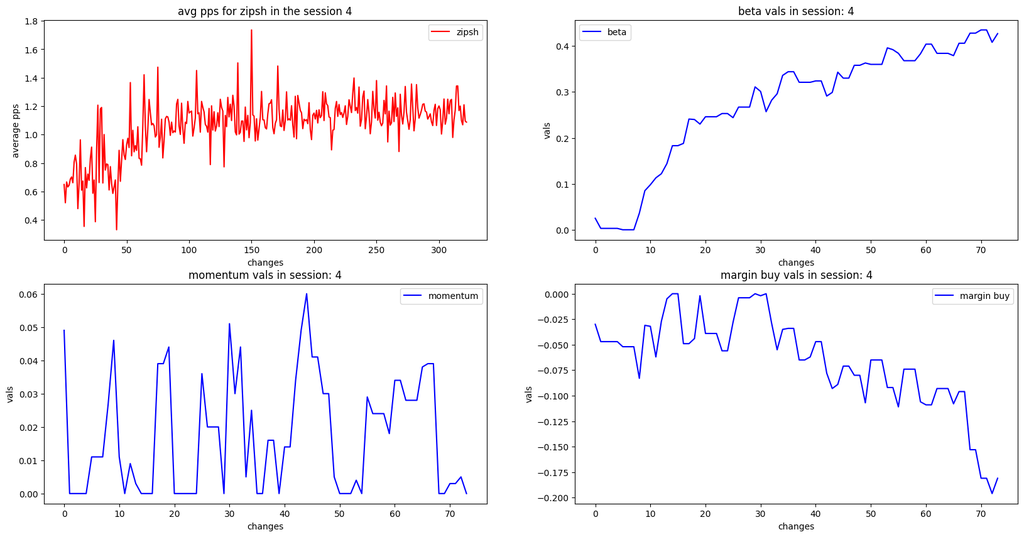

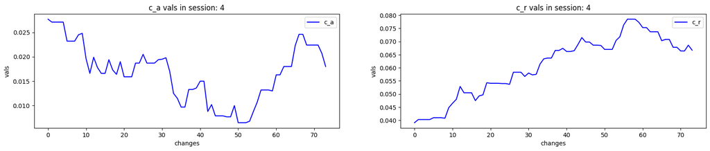

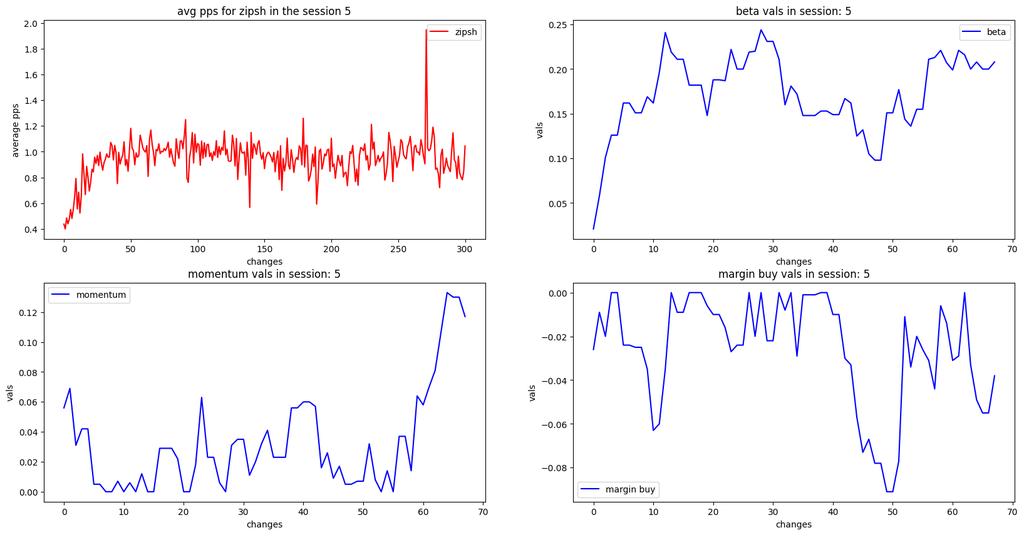

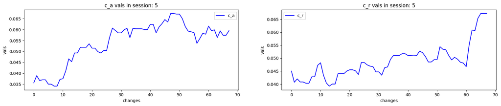

```python
for i in range(5):
    plot_params_pps(total_avg_profit_perS[i], betas[i], momentums[i], c_a[i], c_r[i], initial_margin[i], i+1)
```

The data is tested for normality using Shapiro-wilk, and either a one sample t-test or Wilcoxon t-test is applied to determine statistical significance. For a single sample size as we have here, the Wilcoxon signed-rank test is used to assess whether the median of the sample is equal to zero or close to it, ie no profit was made. The data here is the average increase in profit for the single zipsh trader within each 30 independent runs. The hypothesis here is that zipsh's profit returns are not statistically significant with alpha of 0.05.

The output show that the p value is less than the threshold 0.05, therefore we have enough evidence to reject the null hypothesis. The increase in profit returned by zipsh is statistically significant meaning it does improve over time.

```python
test(total_avg_profit_perS)
```

```
not normal, using wilcoxen
```

```
1.862645149230957e-09
```

D2

```python
start = 0
mid = 60*60*24*15
end = 60*60*24*30
range1 = (50, 100)
range2 = (400, 500)
k = 4
zic_num = 5
zipsh_num = 1
n = 40
order_interval = 30
avg_prof, hyper = run_market_d2(zipsh_num, k, zic_num, range1, range2, start, mid, end, order_interval, "partd2", n, "partd2_avg_balance.csv", "partd2_strats.csv")
betas_2 = hyper[0]
momentums_2 = hyper[1]
c_a_2 = hyper[2]
c_r_2 = hyper[3]
initial_margin_2 = hyper[4]
```

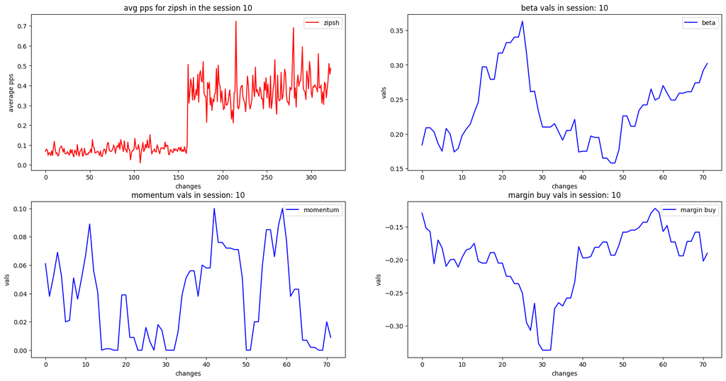

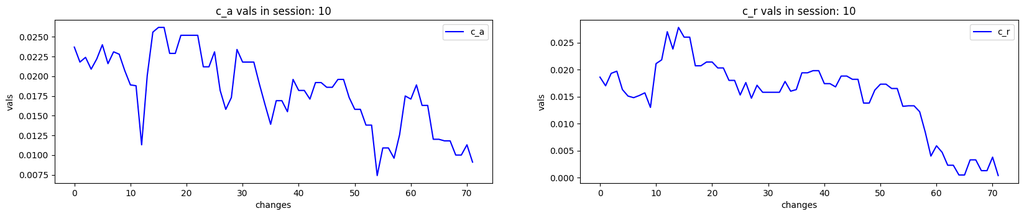

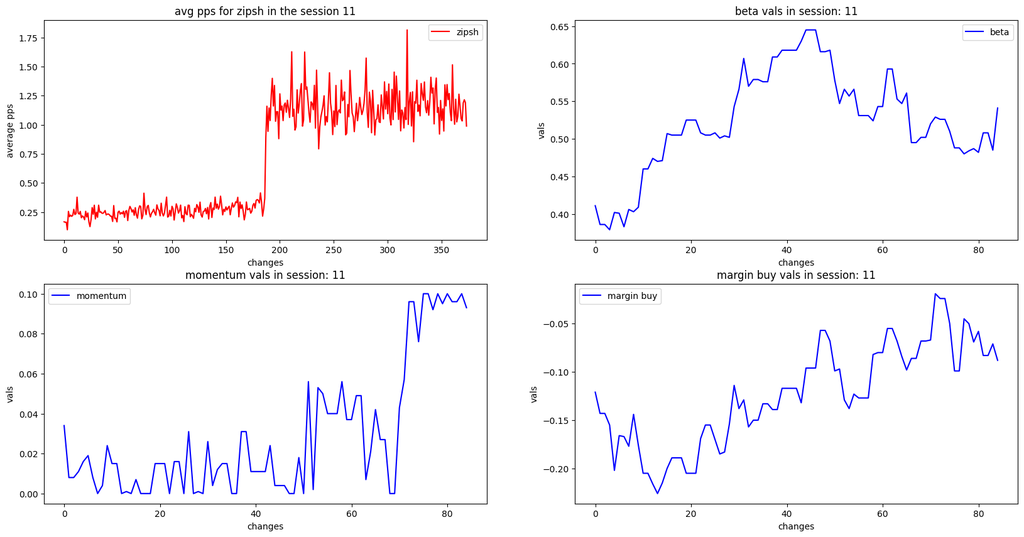

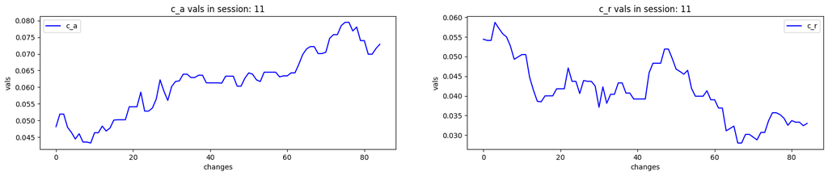

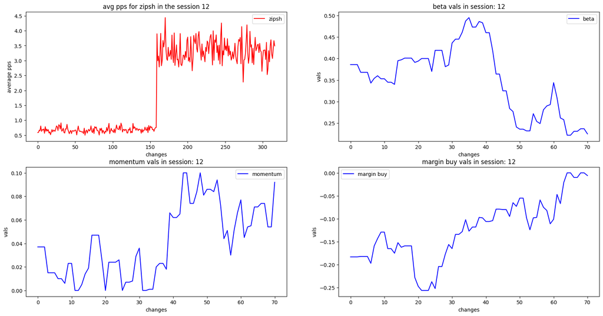

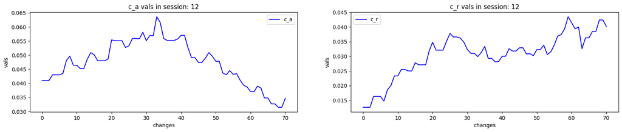

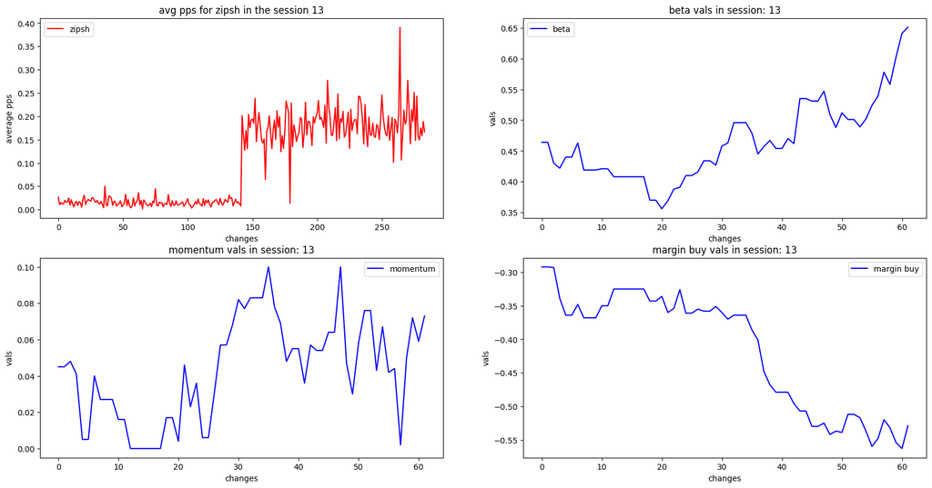

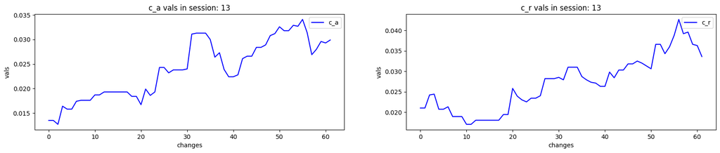

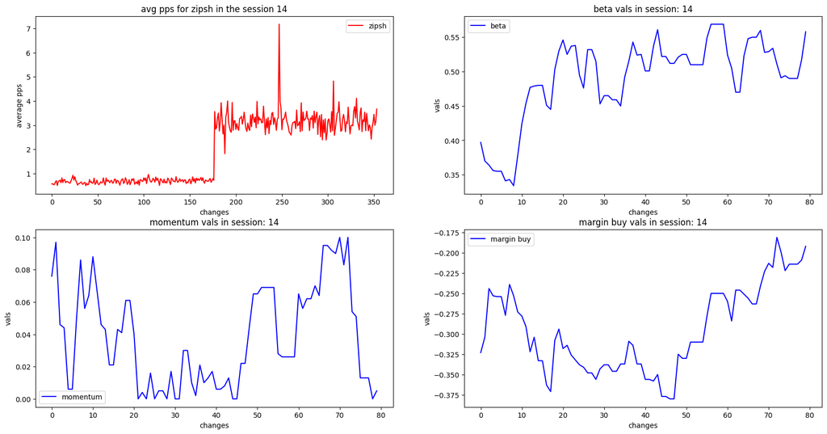

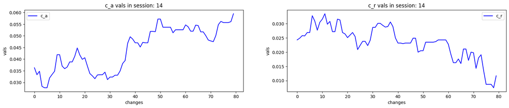

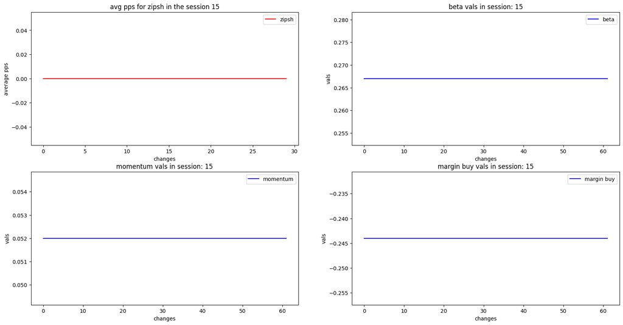

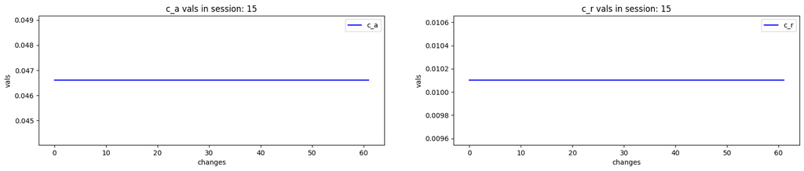

[2 more figures not shown]

```python
for i in range(9, 16): #this range is an overall good representation of the found stuff
    plot_params_pps(avg_prof[i], betas_2[i], momentums_2[i], c_a_2[i], c_r_2[i], initial_margin_2[i], i+1)
```

To do a statistical significance test, data will be test for normality, and then either one sample t-test or Wilcoxon test utilised. Due to the market shock, it is expected for the data not being normalised as the profits will increase as the trades get larger.

```python
test_2(avg_prof)
```

```
not normal, using wilcoxen
```

```
5.388790737562247e-07
```

END OF REPORT. ONLY WORD COUNT BELOW THIS POINT.

```python
# Do not edit this code. It will print the word count of your notebook.
import io
from nbformat import current

def printWordCount(filepath):

    with io.open(filepath, 'r', encoding='utf-8') as f:
        nb = current.read(f, 'json')

    word_count = 0
    for cell in nb.worksheets[0].cells:
        if cell.cell_type == "markdown":
            word_count += len(cell['source'].replace('#', '').lstrip().split(' '))
    print("Word count: " + str(word_count) + ". Limit is 2000 words.")
```

```python
# This should be the final output of your notebook.
# Edit filename to be the same as this filename and then run.
# Save your file before running this code.

this_file_name = "CW-IEFT-template.ipynb" # Enter name of this file here
printWordCount(this_file_name)
```

```
Word count: 1964. Limit is 2000 words.
```